# Telemarketing campaign analysis

### by Liudmila Danilovskaya

## The purpose of investigation is to:

- understand the results of the previous campaigns
- find the trends and relations between features and target variable
- find the factors which facilitate clients to start saving agreements

## The dataset overview

Data were gathered from 2 datasets:

- **customer_info.csv**
- **call_info.csv**

Merging these datasets resulted in a dataset of 20 features.

The following features were analysed:

- **sale** - target variable ('yes', 'no')
- last contact duration
- outcome of the previous campaign
- days since last contacted in previous campaign
- number of contacts in the previous campaign
- consumer confidence index
- day of week of last contact
- month of last contact
- client's age
- client's education
- client's occupation

## Convertion rate by last contact duration

The longer contact with the client the higher chances of their conversion.

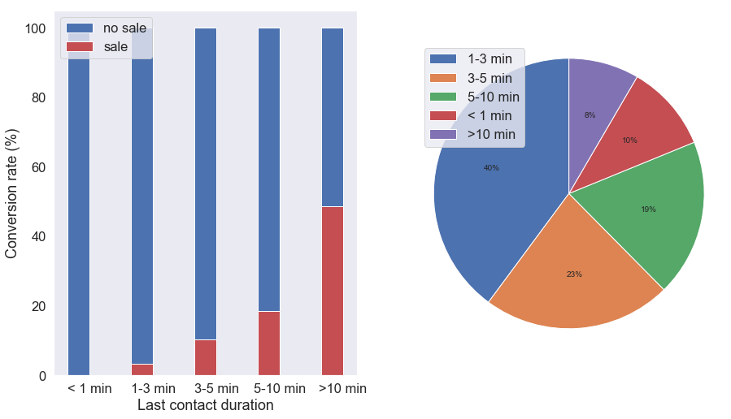

# Conversion rate by outcome of the previous campaigns

Outcome of the previous compaign impacts the conversion rate of the current campaign. If previous campaign was successful, a new campaign has more converted customers than not converted.

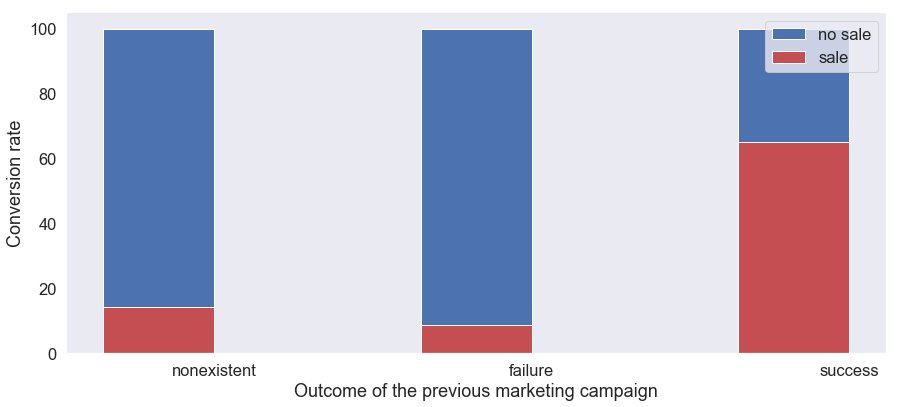

# Days since last contacted in previous campaign

Chances of conversion is higher if time from the last contact is less.

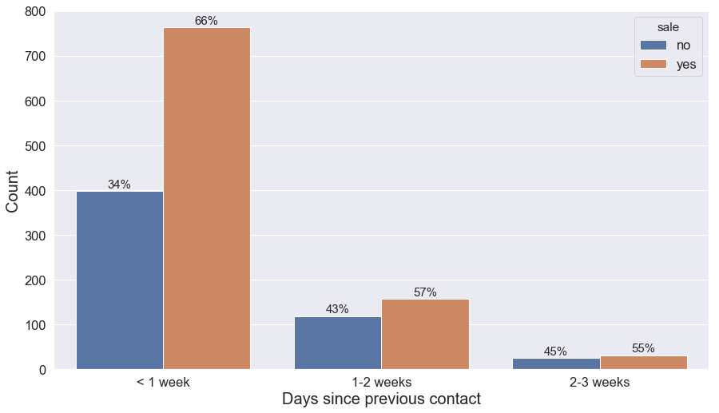

## Conversion rate by the number of contacts during the previous campaign

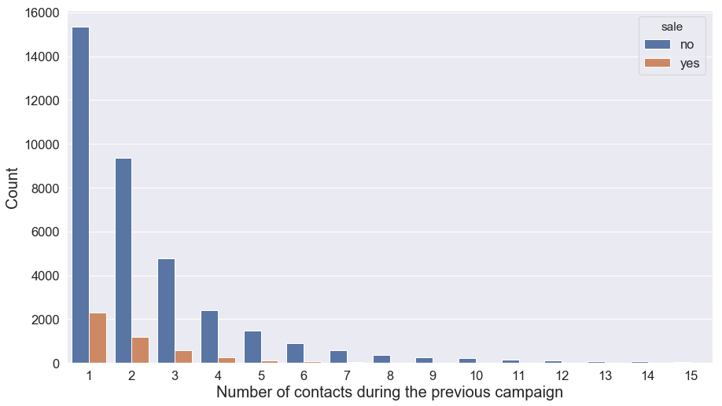

## Conversion rate and consumer confidence index by month

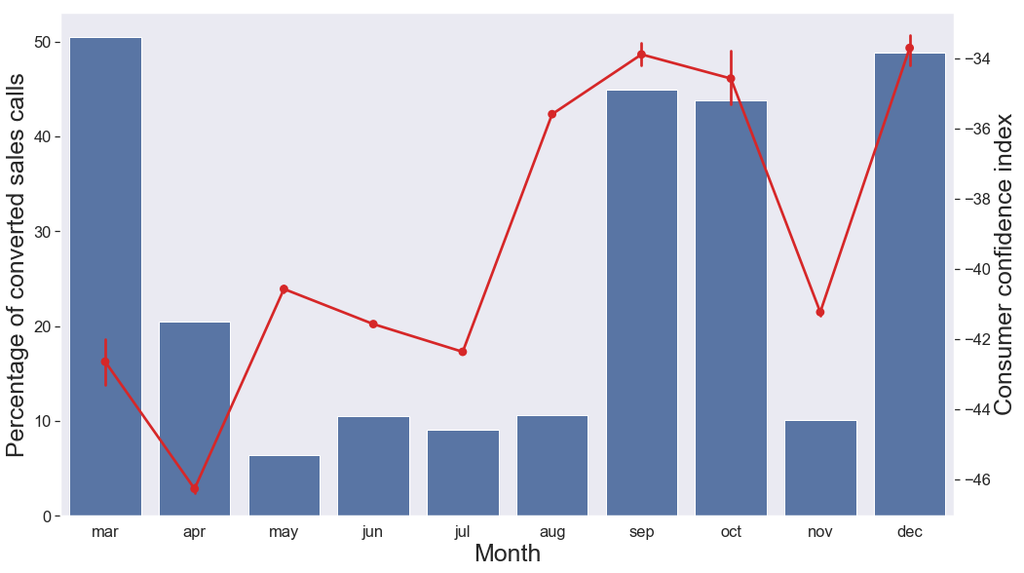

## Conversion rate by day of week

Day of week doesn't show considerable effect on the conversion rate.

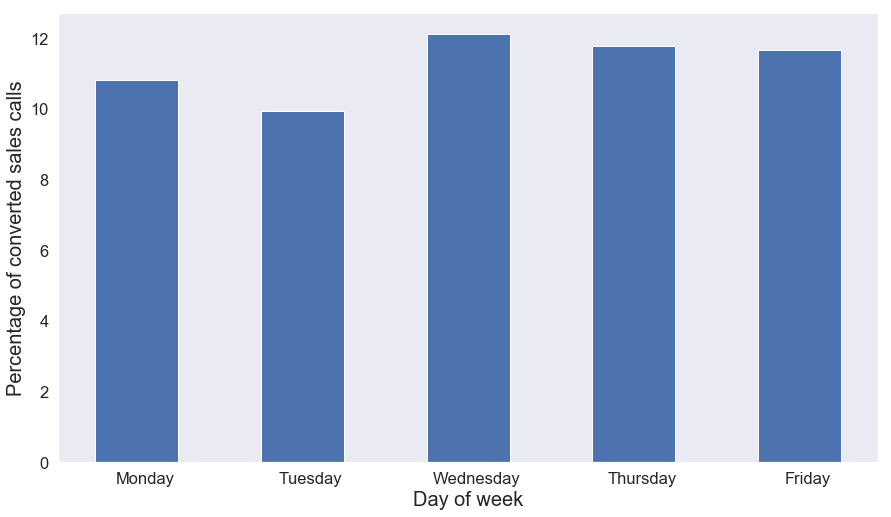

## Age distribution for those who started savings agreement

Most of the customers who started saving agreements were in the age of 25-45, while the mean age is 40 years old.

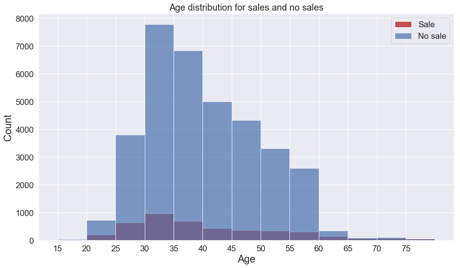

## Conversion rate by education

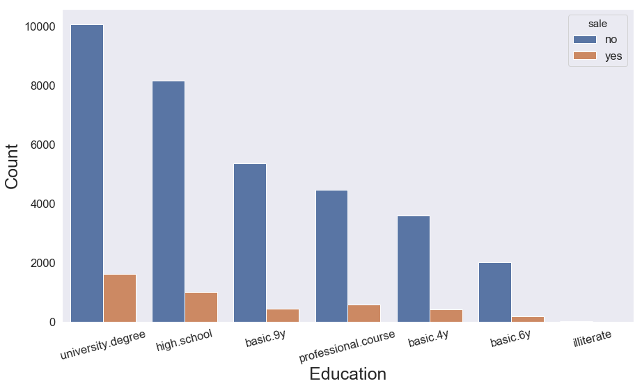

## Conversion rate by occupation

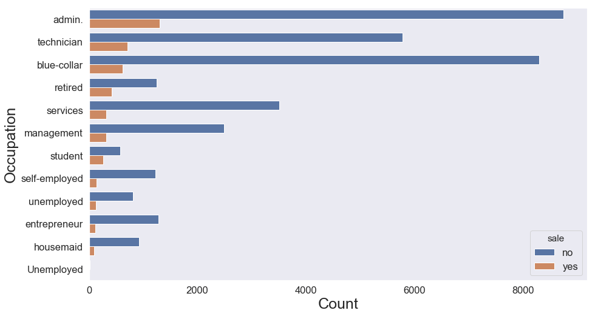